# Html_Amazon_Fresh

## Load data

```python
import pandas as pd

# Load the dataframes from csv files
customer_preferences = pd.read_csv("https://storage.googleapis.com/datalynn-datasets/interview-challenge/technology/Amazon_Fresh/customer_preferences.csv")
orders = pd.read_csv("https://storage.googleapis.com/datalynn-datasets/interview-challenge/technology/Amazon_Fresh/orders.csv")
products = pd.read_csv("https://storage.googleapis.com/datalynn-datasets/interview-challenge/technology/Amazon_Fresh/products.csv")
```

## Q1

**Original Question**:

**Scenario**: Amazon Fresh wants to understand the factors affecting delivery time for its orders. Using the `orders` and `customer_preferences` tables,

**Q**: Build a regression model to predict the delivery time based on customer preferences, location, order amount, and date. How would you handle multicollinearity in this model? Please also provide an explanation of the assumptions made in your chosen regression model.

#### Problem Solving Ideas and Tips:

1. **Data Preparation**: First, we need to join the `orders` and `customer_preferences` tables on `customer_id` to obtain the required data. Then, we will analyze the numerical and categorical variables for any preprocessing needs.
2. **Multicollinearity Handling**: Multicollinearity can affect the stability and precision of the estimation of regression coefficients. We will identify multicollinearity by using tools like the Variance Inflation Factor (VIF), and address it by removing highly correlated predictors, combining predictors, or using regularization techniques like Ridge Regression.
3. **Model Selection**: Linear regression could be a starting point, but it assumes a linear relationship between predictors and response, independence of errors, constant variance, and normality of errors. The assumptions may or may not hold in real-world data, so testing these assumptions would be a crucial step.
4. **Feature Engineering**: Date and location may need to be transformed into actionable features. For example, the day of the week, time of the day, or a specific encoding for location based on zones.
5. **Model Evaluation**: Using metrics like RMSE (Root Mean Square Error), R-squared, etc., for model evaluation.

### Solution

```python
# Imports
import pandas as pd
from sklearn.linear_model import LinearRegression
from sklearn.metrics import mean_squared_error
from sklearn.model_selection import train_test_split
from statsmodels.stats.outliers_influence import variance_inflation_factor
from datetime import datetime


# Merging the tables
data = pd.merge(orders, customer_preferences, on='customer_id')

# Feature Engineering
data['order_date'] = pd.to_datetime(data['order_date'])
data['day_of_week'] = data['order_date'].dt.dayofweek
data['location'] = pd.Categorical(data['location']).codes # Encode location

# Prepare X and y
X = data[['location', 'total_amount', 'day_of_week', 'preference', 'frequency']]
X = pd.get_dummies(X, drop_first=True) # Convert categorical variables to dummy variables
y = data['delivery_time']

# Check for Multicollinearity using VIF
vif_data = pd.DataFrame()
vif_data['feature'] = X.columns
vif_data['VIF'] = [variance_inflation_factor(X.values, i) for i in range(len(X.columns))]
print(vif_data) # If VIF > 5, consider addressing multicollinearity

# Splitting data
X_train, X_test, y_train, y_test = train_test_split(X, y, test_size=0.2, random_state=42)

# Linear Regression Model
model = LinearRegression()
model.fit(X_train, y_train)

# Prediction
y_pred = model.predict(X_test)

# Evaluation
mse = mean_squared_error(y_test, y_pred)
print(f"Root Mean Squared Error: {mse**0.5}")
```

```
                 feature       VIF
0               location  2.450173
1           total_amount  1.806445
2            day_of_week  2.414960
3        preference_Meat  1.582199
4      preference_Snacks  1.770021
5  preference_Vegetables  1.465688
6       frequency_weekly  1.868585
Root Mean Squared Error: 0.9784722391370134
```

#### Assumptions made in the chosen regression model:

1. **Linearity**: Assumes a linear relationship between predictors and response.
2. **Independence of Errors**: The errors are assumed to be independent of each other.
3. **Constant Variance (Homoscedasticity)**: Assumes constant variance of errors across all levels of independent variables.
4. **Normality of Errors**: Assumes that the errors are normally distributed.

## Q2

**Original Question**:

**Scenario**: Amazon Fresh has observed that certain products often run out of stock or are left unsold nearing their expiration date. Using the `products` table,

**Q**: Write Python Pandas code to identify products that have stock levels below a certain threshold or are nearing expiration within a week. Then, using this output, what tree-based model would you use to predict which products will need a restock and why? Include how you would deal with imbalanced data in this model.

### Solution

#### Python Pandas Code:

```python
import pandas as pd

# Assume products_df is the DataFrame containing data from the products table
threshold_stock_level = 10
nearing_expiration_days = 7

# Filter products that are below the stock level threshold or have an expiration date within a week from the current date
filtered_products_df = products[
    (products['stock_level'] < threshold_stock_level) |
    (pd.to_datetime(products['expiration_date']) <= pd.Timestamp.today() + pd.Timedelta(days=nearing_expiration_days))
]

# filtered_products_df will now contain the products that meet the given conditions
```

#### Tree-Based Model (Python Code):

Once you have the output from the previous question, you can use it to build a predictive model. A popular tree-based model for such tasks would be Random Forest.

```python
from sklearn.ensemble import RandomForestClassifier
from sklearn.model_selection import train_test_split
from imblearn.over_sampling import SMOTE
from imblearn.under_sampling import RandomUnderSampler
import warnings
warnings.filterwarnings('ignore')

# Create a new column 'need_restock' to indicate whether a product needs restocking
filtered_products_df['need_restock'] = 1

# If you want to include products not meeting the criteria and mark them as not needing restocking, you can do the following:
products['need_restock'] = 0
products.update(filtered_products_df)

# Now products_df will contain all the products with 'need_restock' marked as 1 or 0

X = products[['stock_level', 'price']] # Feature selection
y = products['need_restock'] # Target variable indicating if restock is needed

# Splitting the data
X_train, X_test, y_train, y_test = train_test_split(X, y, test_size=0.2, random_state=42)

# Handling Imbalanced Data using SMOTE
under = RandomUnderSampler(sampling_strategy=0.5)
X_train_resampled, y_train_resampled = under.fit_resample(X_train, y_train)
smote = SMOTE(sampling_strategy=0.1)
# X_train_resampled, y_train_resampled = smote.fit_resample(X_train, y_train)
X_train_resampled, y_train_resampled = under.fit_resample(X_train_resampled, y_train_resampled)

# Random Forest Model
model = RandomForestClassifier()
model.fit(X_train_resampled, y_train_resampled)
```

```
RandomForestClassifier()
```

```
Accuracy: 0.70
Precision: 0.84
Recall: 0.76
F1-Score: 0.80

Confusion Matrix:
[[ 24  23]
 [ 36 117]]
```

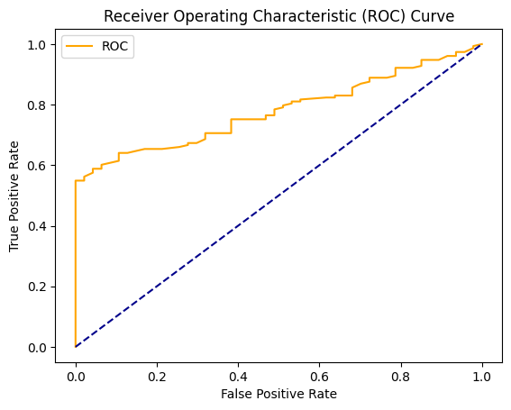

```
AUC Score: 0.78
```

```python
from sklearn.metrics import accuracy_score, precision_score, recall_score, f1_score, confusion_matrix, roc_curve, roc_auc_score
import matplotlib.pyplot as plt

# 1. Predict the target variable on the test set
y_pred = model.predict(X_test)

# 2. Calculate and print the metrics
accuracy = accuracy_score(y_test, y_pred)
precision = precision_score(y_test, y_pred)
recall = recall_score(y_test, y_pred)
f1 = f1_score(y_test, y_pred)

print(f"Accuracy: {accuracy:.2f}")
print(f"Precision: {precision:.2f}")
print(f"Recall: {recall:.2f}")
print(f"F1-Score: {f1:.2f}")

# Confusion matrix
cm = confusion_matrix(y_test, y_pred)
print("\nConfusion Matrix:")
print(cm)

# ROC Curve
y_probs = model.predict_proba(X_test)[:, 1]  # Probabilities of the positive class
fpr, tpr, thresholds = roc_curve(y_test, y_probs)
plt.plot(fpr, tpr, color='orange', label='ROC')
plt.plot([0, 1], [0, 1], color='darkblue', linestyle='--')
plt.xlabel('False Positive Rate')
plt.ylabel('True Positive Rate')
plt.title('Receiver Operating Characteristic (ROC) Curve')
plt.legend()
plt.show()

# AUC Score
auc_score = roc_auc_score(y_test, y_probs)
print(f"AUC Score: {auc_score:.2f}")
```

## Q3

**Original Question**:

**Scenario**: Amazon Fresh is interested in predicting demand in different localities to ensure efficient delivery and inventory management. Using the `orders` and `products` tables,

**Q**: What time series model would you use to forecast demand for specific product categories in different localities? Explain the model and how you would interpret the results. Also, write an SQL query to find the correlation between the price of the products and the total amount of orders in each locality.

#### Problem Solving Ideas and Tips

To forecast demand for specific product categories in different localities, we would need to consider the time series patterns in the data, such as trend, seasonality, and noise. Depending on the underlying characteristics of the data, different models could be suitable.

### Solution

#### Time Series Model for Forecasting

1. **Data Preparation**: Group the data by product category and locality, and then by order date to create time series data.
2. **Model Selection**: A popular approach for this kind of forecasting is the ARIMA (Autoregressive Integrated Moving Average) model. If the data exhibits clear seasonal patterns, the Seasonal ARIMA (SARIMA) model might be more appropriate.
3. **Model Interpretation**: Interpretation of the model would involve understanding how past values (autoregressive terms) and past errors (moving average terms) influence future forecasts. The integration term helps to make the series stationary if it is not.

A code snippet for implementing SARIMA using Python (assuming you have created time series data for a specific category and locality):

```
from statsmodels.tsa.statespace.sarimax import SARIMAX

# Define the model
model = SARIMAX(time_series_data, order=(p, d, q), seasonal_order=(P, D, Q, S))

# Fit the model
results = model.fit()

# Make forecasts
forecasts = results.get_forecast(steps=forecast_steps)
```

p, d, q are the non-seasonal parameters, and P, D, Q, S are the seasonal parameters. These should be selected based on statistical analysis, such as ACF and PACF plots, and grid search.

Now, for the SQL query to find the correlation between the price of the products and the total amount of orders in each locality. This can be done using SQLite3, with a join between the `orders` and `products` tables.

```python
import sqlite3

# Create a database connection
conn = sqlite3.connect(':memory:')

# Convert pandas dataframes to SQL tables
orders.to_sql('orders', conn, if_exists='replace', index=False)
products.to_sql('products', conn, if_exists='replace', index=False)

# SQL query to join orders and products based on product category and location
query = """
SELECT
    o.order_date,
    p.category,
    o.location,
    SUM(o.total_amount) as total_amount
FROM
    orders o
JOIN
    products p
ON
    o.order_id = p.product_id
GROUP BY
    o.order_date, p.category, o.location
"""

time_series_data = pd.read_sql_query(query, conn)

# Filter for specific category and location
filtered_data = time_series_data[
    (time_series_data['category'] == 'Snacks') &
    (time_series_data['location'] == 'Houston')
].set_index('order_date')
```

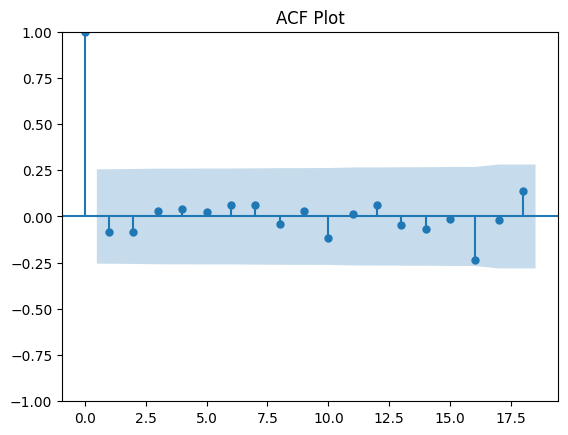

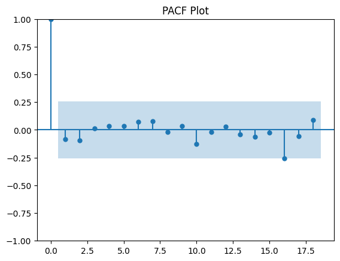

```python
import matplotlib.pyplot as plt
from statsmodels.graphics.tsaplots import plot_acf, plot_pacf

# ACF plot
plot_acf(filtered_data['total_amount'])
plt.title('ACF Plot')
plt.show()

# PACF plot
plot_pacf(filtered_data['total_amount'])
plt.title('PACF Plot')
plt.show()
```

Based on these observations, here's the adjusted SARIMAX model specification:

```python
from statsmodels.tsa.statespace.sarimax import SARIMAX
import warnings
warnings.filterwarnings('ignore')

# Define the model
model = SARIMAX(filtered_data['total_amount'], order=(1, 1, 1), seasonal_order=(1, 1, 1, 12))

# Fit the model
results = model.fit()

# Make forecasts for the next 5 periods
forecasts = results.get_forecast(steps=5)
print(forecasts.predicted_mean)
```

```
59     32.737040
60     60.967861
61     31.708382
62     75.210726
63    109.558897
Name: predicted_mean, dtype: float64
```

```python
query = """
SELECT
    o.location,
    SUM(o.total_amount) AS total_order_amount,
    AVG(p.price) AS average_product_price
FROM
    orders o
JOIN
    products p
ON
    o.order_id = p.product_id
GROUP BY
    o.location
"""

# Execute the query
cursor = conn.cursor()
cursor.execute(query)

# Fetch the results
results = cursor.fetchall()
locations, total_order_amount, average_product_price = zip(*results)

# Calculate the correlation
import numpy as np
correlation = np.corrcoef(total_order_amount, average_product_price)[0, 1]

print("Correlation:", correlation)

# Close the connection
conn.close()
```

```
Correlation: 0.17558905161819957
```

This correlation would give you an indication of how the price of products is related to the total amount of orders in different localities. A positive correlation might indicate that higher-priced products are ordered more in certain localities, and vice versa.